# tutorial-peach-1.R

ana

Mon May 7 21:04:27 2018

# Temperature forecasting with GRU

First steps, create an directory, download the dataset, unzip it. Let’s look the data

```r
library(tibble)
library(readr)
peach_four_sensors <- read_csv("~/phd-repos/RNN-keras-prediction/peach_four_sensors.csv")
#View(peach_four_sensors)
data <- peach_four_sensors
glimpse(data)
```

```
## Observations: 977
## Variables: 6
## $ Time                      <dttm> 2016-09-09 21:00:00, 2016-09-09 21:...
## $ `00-17-0d-00-00-30-60-ef` <dbl> 32.16222, 31.25000, 30.52950, 29.922...
## $ `00-17-0d-00-00-38-0f-66` <dbl> 36.29889, 35.61947, 34.60050, 34.281...
## $ `00-17-0d-00-00-3f-f8-20` <dbl> 34.39000, 33.21158, 32.46050, 31.754...
## $ `00-17-0d-00-00-3f-fe-87` <dbl> 33.56750, 33.06250, 32.40944, 32.289...
## $ `00-17-0d-00-00-3f-fe-88` <dbl> 35.28222, 34.37895, 33.68263, 33.378...
```

Plot the temperature °C

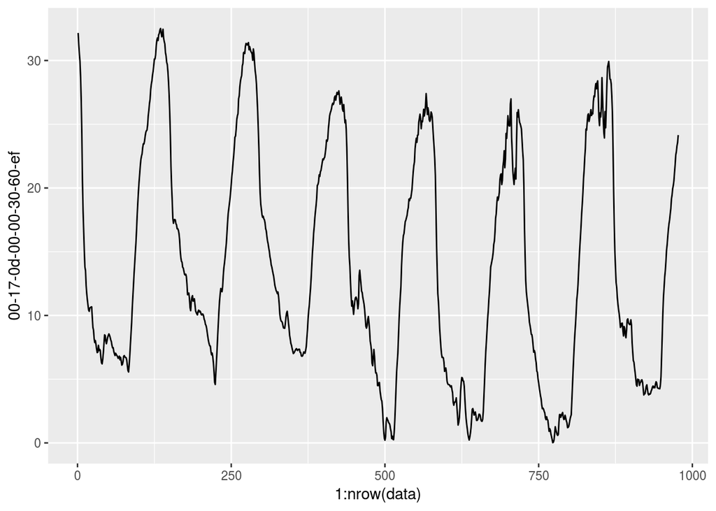

```r
library(ggplot2)
ggplot(data, aes(x = 1:nrow(data), y = `00-17-0d-00-00-30-60-ef`)) + geom_line()
```

Converting the data into a floating-point matrix Quito columna Date

```r
data <- data.matrix(data[,-1])
```

Normalizing the data

```r
train_data <- data[1:500,]
mean <- apply(train_data, 2, mean)
std <- apply(train_data, 2, sd)
data <- scale(data, center = mean, scale = std)
```

## GLOSARY

*Mini-batch or batch* A small set of samples (typically between 8 and 128) that are processed simultaneously by the model. The number of samples is often a power of 2, to facilitate memory allocation on GPU. When training, a mini-batch is used to compute a single gradient-descent update applied to the weights of the model.

## Generator yielding timeseries samples and their targets

*lookback* How many timesteps back the input data should go.

*delay* How many timesteps in the future the target should be.

*min_index* and *max_index* —Indices in the data array that delimit which time-steps to draw from. This is useful for keeping a segment of the data for validation and another for testing.

*shuffle* —Whether to shuffle the samples or draw them in chronological order.

*batch_size* —The number of samples per batch.

*step* —The period, in timesteps, at which you sample data. You’ll set it to 6 in order to draw one data point every hour.

```r
generator <- function(data, lookback, delay, min_index, max_index, shuffle = FALSE, batch_size = 128, step = 6) {
  if (is.null(max_index)) max_index <- nrow(data) - delay - 1
  i <- min_index + lookback
  function() {
    if (shuffle) {
      rows <- sample(c((min_index+lookback):max_index), size = batch_size)
    } else {
      if (i + batch_size >= max_index)
        i <<- min_index + lookback
      rows <- c(i:min(i+batch_size, max_index))
      i <<- i + length(rows)
    }
    samples <- array(0, dim = c(length(rows),
                                lookback / step,
                                dim(data)[[-1]]))
    targets <- array(0, dim = c(length(rows)))
    for (j in 1:length(rows)) {
      indices <- seq(rows[[j]] - lookback, rows[[j]],
                     length.out = dim(samples)[[2]])
      samples[j,,] <- data[indices,]
      targets[[j]] <- data[rows[[j]] + delay,2]
    }
    list(samples, targets)
  }
}
```

The i variable contains the state that tracks the next window of data to return, so it’s updated using superassignment ( i <<- i + length(rows) ).

## Preparing the training, validation, and test generators

```r
library(keras)
```

Observations will go back 12 hours

```r
lookback <- 12*6
```

Observations will be sampled at one data point per hour.

```r
step <- 6
```

Targets will be 3 hours in the future.

```r
delay <- 3 * 6
batch_size <- 32
train_gen <- generator(
  data,
  lookback = lookback,
  delay = delay,
  min_index = 1,
  max_index = 500,
  shuffle = TRUE,
  step = step,
  batch_size = batch_size
)
val_gen = generator(
  data,
  lookback = lookback,
  delay = delay,
  min_index = 501,
  max_index = 659,
  step = step,
  batch_size = batch_size
)
test_gen <- generator(
  data,
  lookback = lookback,
  delay = delay,
  min_index = 797,
  max_index = NULL,
  step = step,
  batch_size = batch_size
)
val_steps <- (797 - 501 - lookback) / batch_size
test_steps <- (nrow(data) - 797 - lookback) / batch_size
```

## Computing the common-sense baseline MAE

```r
evaluate_naive_method <- function() {
  batch_maes <- c()
  for (step in 1:val_steps) {
    c(samples, targets) %<-% val_gen()
    preds <- samples[,dim(samples)[[2]],2]
    mae <- mean(abs(preds - targets))
    batch_maes <- c(batch_maes, mae)
  }
  print(mean(batch_maes))
}
evaluate_naive_method()
```

```
## [1] 0.6607259
```

Training and evaluating a densely connected model

```r
model <- keras_model_sequential() %>%
  layer_flatten(input_shape = c(lookback / step, dim(data)[-1])) %>%
  layer_dense(units = 32, activation = "relu") %>%
  layer_dense(units = 1)
model %>% compile(
  optimizer = optimizer_rmsprop(),
  loss = "mae"
)
history <- model %>% fit_generator(
  train_gen,
  steps_per_epoch = 100,
  epochs = 20,
  validation_data = val_gen,
  validation_steps = val_steps
)
```

Ploting results

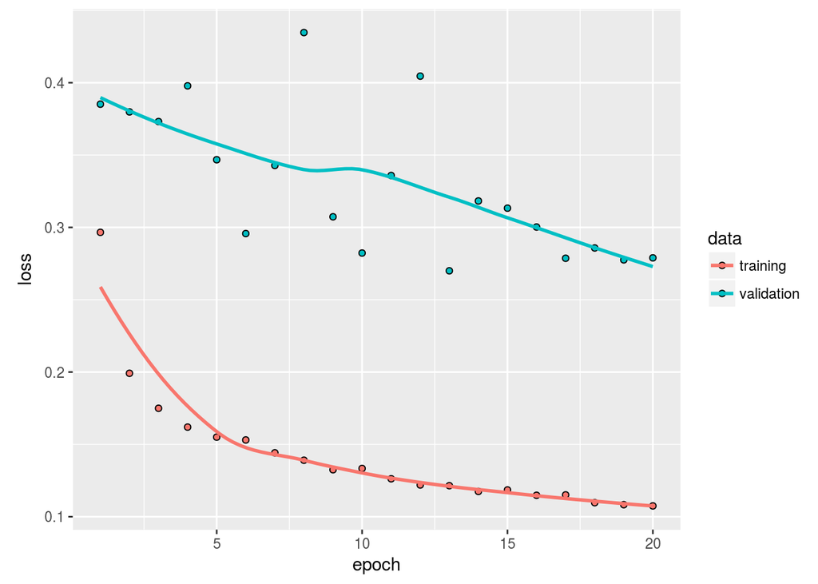

```r
plot(history)
```

## A first recurrent baseline

Training and evaluating a model with layer_gru

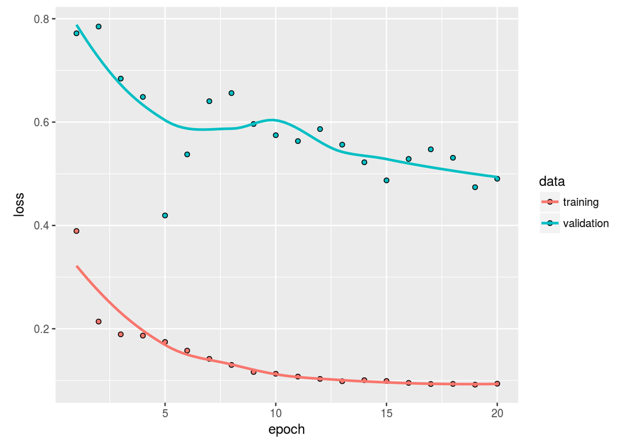

```r
model <- keras_model_sequential() %>%
  layer_gru(units = 32, input_shape = list(NULL, dim(data)[[-1]])) %>%
  layer_dense(units = 1)
model %>% compile(
  optimizer = optimizer_rmsprop(),
  loss = "mae"
)
history <- model %>% fit_generator(
  train_gen,
  steps_per_epoch = 100,
  epochs = 20,
  validation_data = val_gen,
  validation_steps = val_steps
)
plot(history)
```